# NumPy vs APL

https://youtu.be/ZB0IJMRpbRE

@MaxCan-Code "Max Sun APL"

# NumPy vs APL

- Going slow and easy, we have an hour
- APL NumPy side-by-side
- Goal: aware of APL as another tool
- Non-goal: switch
- Cover briefly then come back for Qs
- Intentionally left out details so please ask as I go

## About me

- Applied math in school
- Knew APL from YouTube
- Learned APL on the job last Jan (https://bcaresearch.com customer of Dyalog)

## What we'll do

1. Simple Moore's Law model
2. Real data (CSV)
3. Perform linear regression and predict exponential growth using ordinary least squares (tldr line of best fit)
- Compare exponential growth constants between models
- Save and share:
  - NumPy zipped file `*.npz`
  - APL namespace file `*.apln`
  - CSV
- Chat, happy little demos?

Modified from https://numpy.org/numpy-tutorials/content/mooreslaw-tutorial.html

## What we need

- Python (packages):
  - NumPy
  - Matplotlib
- Dyalog APL:
  - SharpPlot (included) (OOP)
  - Py'n'APL (optional, external, open source)

APL trigger warning

- Butchered NumPy-style APL for comparison
- APL users, sorry

```python
import matplotlib.pyplot as plt
import numpy as np
from pynapl import APL
apl = APL.APL()
run = apl.eval
```

[output not shown]

[output not shown]

## Model

`Moores_law(year) = (e^B_M) × (e^(A_M × year))`

`A_M = (log 2) ÷ 2`

`B_M = (log 2250) - A_M × 1971`

```python
     #        exp←*
     #        log←*○
     A_M = np.log(2) / 2
run("A_M ←     (⍟ 2) ÷ 2")

     B_M = np.log(2250) - A_M * 1971
run("B_M ←     (⍟ 2250) - A_M × 1971")

     Moores_law = lambda year: np.exp(B_M) * np.exp(A_M * year)
run("Moores_law ← {      year←⍵ ⋄  (* B_M) ×      *(A_M × year)} ⋄")

[A_M, B_M], run("A_M B_M")
```

```
([np.float64(0.34657359027997264), np.float64(-675.3778609466276)],
 [0.3465735902799726, -675.3778609466276])
```

In 1971, there were 2250 transistors. Use `Moores_law` to predict how many in 1973.

```python
ML_1971 = Moores_law(1971)
ML_1973 = Moores_law(1973)
print("In 1973, G. Moore expects {:.0f} transistors on Intels chips".format(ML_1973))
print("This is x{:.2f} more transistors than 1971".format(ML_1973 / ML_1971))
```

```
In 1973, G. Moore expects 4500 transistors on Intels chips
This is x2.00 more transistors than 1971
```

```python
run("""
ML_1971←Moores_law 1971
ML_1973←Moores_law 1973

_←'.format←⍕'
⎕←'In 1973, G. Moore expects ',(1↓0⍕ML_1973),' transistors on Intels chips'
⎕←'This is x',(1↓2⍕ML_1973÷ML_1971),' more transistors than 1971'
""");
```

```
In 1973, G. Moore expects 4500 transistors on Intels chips
This is x2.00 more transistors than 1971
```

## Loading historical data

- Transistor count each year in CSV
- Inspect before load
- Save year & count columns to `data`.

Print first 10 rows of `transistor_data.csv`. The columns are

| Processor | MOS transistor count | Date of Introduction | Designer | MOSprocess | Area |
| --- | --- | --- | --- | --- | --- |
| Intel 4004 (4-bit 16-pin) | 2250 | 1971 | Intel | "10,000 nm" | 12 mm² |
| ... | ... | ... | ... | ... | ... |

```python
! head transistor_data.csv
```

```
Processor,MOS transistor count,Date of Introduction,Designer,MOSprocess,Area
Intel 4004 (4-bit  16-pin),2250,1971,Intel,"10,000 nm",12 mm²
Intel 8008 (8-bit  18-pin),3500,1972,Intel,"10,000 nm",14 mm²
NEC μCOM-4 (4-bit  42-pin),2500,1973,NEC,"7,500 nm",?
Intel 4040 (4-bit  16-pin),3000,1974,Intel,"10,000 nm",12 mm²
Motorola 6800 (8-bit  40-pin),4100,1974,Motorola,"6,000 nm",16 mm²
Intel 8080 (8-bit  40-pin),6000,1974,Intel,"6,000 nm",20 mm²
TMS 1000 (4-bit  28-pin),8000,1974,Texas Instruments,"8,000 nm",11 mm²
MOS Technology 6502 (8-bit  40-pin),4528,1975,MOS Technology,"8,000 nm",21 mm²
Intersil IM6100 (12-bit  40-pin; clone of PDP-8),4000,1975,Intersil,,
```

```python
run("""
⎕←↑'UTF-8'∘⎕UCS¨⎕UCS¨⎕SH'head transistor_data.csv'
⎕←''
⎕←↑⎕SH'head transistor_data.csv'
""");
```

```
Processor,MOS transistor count,Date of Introduction,Designer,MOSprocess,Area
Intel 4004 (4-bit  16-pin),2250,1971,Intel,"10,000 nm",12 mm²
Intel 8008 (8-bit  18-pin),3500,1972,Intel,"10,000 nm",14 mm²
NEC μCOM-4 (4-bit  42-pin),2500,1973,NEC,"7,500 nm",?
Intel 4040 (4-bit  16-pin),3000,1974,Intel,"10,000 nm",12 mm²
Motorola 6800 (8-bit  40-pin),4100,1974,Motorola,"6,000 nm",16 mm²
Intel 8080 (8-bit  40-pin),6000,1974,Intel,"6,000 nm",20 mm²
TMS 1000 (4-bit  28-pin),8000,1974,Texas Instruments,"8,000 nm",11 mm²
MOS Technology 6502 (8-bit  40-pin),4528,1975,MOS Technology,"8,000 nm",21 mm²
Intersil IM6100 (12-bit  40-pin; clone of PDP-8),4000,1975,Intersil,,

Processor,MOS transistor count,Date of Introduction,Designer,MOSprocess,Area
Intel 4004 (4-bit  16-pin),2250,1971,Intel,"10,000Â nm",12Â mmÂ²
Intel 8008 (8-bit  18-pin),3500,1972,Intel,"10,000Â nm",14Â mmÂ²
NEC Î¼COM-4 (4-bit  42-pin),2500,1973,NEC,"7,500Â nm",?
Intel 4040 (4-bit  16-pin),3000,1974,Intel,"10,000Â nm",12Â mmÂ²
Motorola 6800 (8-bit  40-pin),4100,1974,Motorola,"6,000Â nm",16Â mmÂ²
Intel 8080 (8-bit  40-pin),6000,1974,Intel,"6,000Â nm",20Â mmÂ²
TMS 1000 (4-bit  28-pin),8000,1974,Texas Instruments,"8,000Â nm",11Â mmÂ²
MOS Technology 6502 (8-bit  40-pin),4528,1975,MOS Technology,"8,000Â nm",21Â mmÂ²
Intersil IM6100 (12-bit  40-pin; clone of PDP-8),4000,1975,Intersil,,
```

Only need columns 2 & 3

`np.loadtxt`:

- `delimiter = ','`
- `usecols = [1,2]`: import cols 2 & 3
- `skiprows = 1`: skip header row

```python
data = np.loadtxt("transistor_data.csv", delimiter=",", usecols=[1, 2], skiprows=1)
```

```python
run("""
csv←(⎕CSV⍠'Separator' ',')'transistor_data.csv'⍬ 4
data←1↓csv[;2 3]
data←1⊃⎕CSV'transistor_data.csv'⍬(0 4 4 0 0 0)1
""");

# csv = np.loadtxt("transistor_data.csv") # Value Error: could not convert string to float
# data = csv[1:, 1:3]
```

- Assign `data` to `year` and `transistor_count`
- Print first 10 values (`[:10]`)

```python
year = data[:, 1]  # grab the second column and assign
transistor_count = data[:, 0]  # grab the first column and assign

print("year:\t\t", year[:10])
print("trans. cnt:\t", transistor_count[:10])
```

```
year:		 [1971. 1972. 1973. 1974. 1974. 1974. 1974. 1975. 1975. 1975.]
trans. cnt:	 [2250. 3500. 2500. 3000. 4100. 6000. 8000. 4528. 4000. 5000.]
```

```python
apl.eval("""
year←data[;2]⊣'  ⍝ grab the second column and assign'
transistor_count←data[;1]⊣'  ⍝ grab the first column and assign'

⎕←'year:		',10↑year
⎕←'trans. cnt:	',10↑transistor_count ⋄
""");
```

```
year:		 1971 1972 1973 1974 1974 1974 1974 1975 1975 1975
trans. cnt:	 2250 3500 2500 3000 4100 6000 8000 4528 4000 5000
```

Goal: solve `yi = A × year + B` for `A`, `B`

```python
yi = np.log(transistor_count)
run("yi←  ⍟ transistor_count");
```

Use least squares

```python
model = np.polynomial.Polynomial.fit(year, yi, deg=1)
model = model.convert()
model
```

$x \mapsto \text{-666.32640635} + \text{0.34163208}\,x$

```python
run("""
_←'https://aplcart.info?q=linear%20fit'
_←'matrix div ⌹ ⎕÷'
model←yi⌹(1,⍪year)
(B A)←model
⎕←'x' ' ' '↦'(1↓9⍕B)'+'(1↓9⍕A)'x'
""");
```

```
x ↦ ¯666.326406352 + 0.341632083 x
```

The individual parameters `A` and `B` are the coefficients of our linear model:

```python
B, A = model
# (B A)←model
```

Increase rate = `e^(2 × A)`

```python
print(f"Rate of semiconductors added on a chip every 2 years: {np.exp(2 * A):.2f}")
```

```
Rate of semiconductors added on a chip every 2 years: 1.98
```

```python
run("""
⎕←'Rate of semiconductors added on a chip every 2 years: ',1↓2⍕*2×A
""");
```

```
Rate of semiconductors added on a chip every 2 years: 1.98
```

Plot & compare:

- Least squares
- Moore's law
- Real world data

style sheet: `fivethirtyeight`

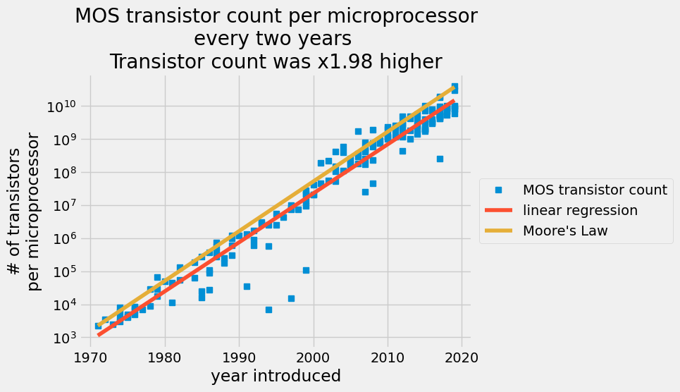

```python
transistor_count_predicted = np.exp(B) * np.exp(A * year)
transistor_Moores_law = Moores_law(year)
plt.style.use("fivethirtyeight")
plt.semilogy(year, transistor_count, "s", label="MOS transistor count")
plt.semilogy(year, transistor_count_predicted, label="linear regression")


plot1 = plt.plot(year, transistor_Moores_law, label="Moore's Law")
plt.title(
    "MOS transistor count per microprocessor\n"
    + "every two years \n"
    + "Transistor count was x{:.2f} higher".format(np.exp(A * 2))
)
plt.xlabel("year introduced")
plt.legend(loc="center left", bbox_to_anchor=(1, 0.5))
plt.ylabel("# of transistors\nper microprocessor")
```

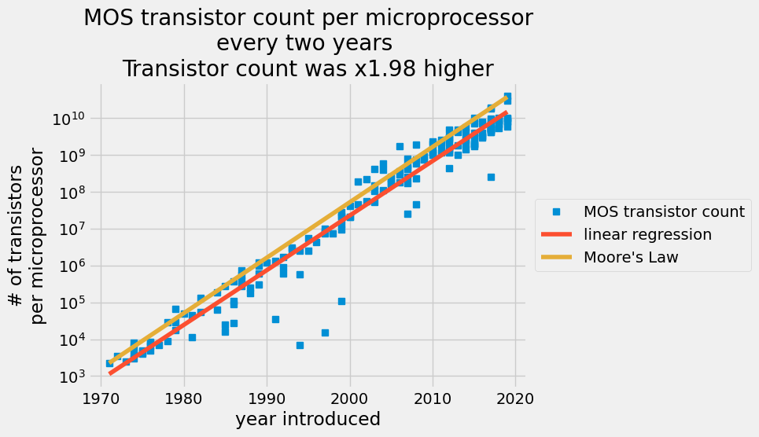

```python
plot1[0].figure
```

```python
run("""
_←']Chart ⍝ useful, windows only'
_538←{_sp←⍵
    _←_sp.SetLineStyles do Causeway.LineStyle.Solid
    FromHtml←Causeway.ColorTranslator.{FromHtml'#',⍵}
    _←'FromHtml←{256⊥255,16⊥⍉3 2⍴¯1+⍵⍳⍨⎕D,⎕C ⎕A}'
    _←'https://github.com/matplotlib/matplotlib/blob/main/lib/matplotlib/mpl-data/stylelib/fivethirtyeight.mplstyle'
    _←_sp.SetColors do⊂Causeway.{Color.(⍵)}FromHtml¨'008fd5' 'fc4f30' 'e5ae38' '6d904f' '8b8b8b' '810f7c'
    _←_sp.SetBackground do Causeway.{Color.(⍵)}FromHtml'f0f0f0'
    _←_sp.SetKeyBackground do Causeway.{Color.(⍵)}FromHtml'f0f0f0'
    _←_sp.SetAxisStyle do(Causeway.{Color.(⍵)}FromHtml'cbcbcb')Causeway.LineStyle.Solid 0.5
    _←_sp.SetGridLineStyle do(Causeway.{Color.(⍵)}FromHtml'cbcbcb')Causeway.LineStyle.Solid 0.5
    _←_sp.SetPenWidths do 3
    font←'DejaVu Sans'
    _←_sp.SetHeadingFont do font
    _←_sp.SetCaptionFont do font
    _←_sp.SetLabelFont do font
    _←_sp.SetKeyFont do font
    _sp.KeyStyle←Causeway.KeyStyles.(Boxed+Vertical+MiddleAlign)
    _sp.XAxisStyle←Causeway.XAxisStyles.CenteredCaption
    _sp.YAxisStyle←Causeway.YAxisStyles.CenteredCaption
    _sp.YLabelFormat←'0.0E00'
    _sp.ScatterPlotStyle←Causeway.ScatterPlotStyles.GridLines
    _sp.LineGraphStyle←Causeway.LineGraphStyles.GridLines
    _sp}
do←{⍎'⍺⍺ ⍵ ⋄ 0' ⋄ ⍺⍺}
'InitCauseway'⎕CY'sharpplot'
InitCauseway ⍬
sp←⎕NEW Causeway.SharpPlot
""");
```

```python
import IPython
IPython.display.SVG(run("""
transistor_count_predicted←(*B)×(*A×year)
transistor_Moores_law←Moores_law year
sp←_538 sp
_←sp.SetKeyText do'MOS transistor count' 'linear regression' 'Moore''s Law'
sp.Heading←'MOS transistor count per microprocessor',(⎕UCS 10),'every two years',(⎕UCS 10),'Transistor count was x ',(1↓2⍕*A×2),' higher'
sp.XCaption←'year introduced'
sp.YCaption←'# of transistors',(⎕UCS 10),'per microprocessor'
sp.YAxisStyle←sp.YAxisStyle+Causeway.YAxisStyles.LogScale
sp.KeyStyle←sp.KeyStyle+Causeway.KeyStyles.RightAlign
_←sp.SetMarkers do Causeway.Marker.Block
_←sp.SetMargins do 80 30 50 150
_←sp.SetXTickMarks do 10
_←sp.SetYTickMarks do 2
_←sp.DrawScatterPlot do(transistor_count)year
_←sp.DrawLineGraph do transistor_count_predicted year
_←sp.DrawLineGraph do transistor_Moores_law year
sp.RenderSvg ⍬
"""))
```

[figure not shown]

```python
IPython.display.SVG(run("sp.RenderSvg ⍬"))
```

[figure not shown]

Zoom in on `year == 2017`, compare:

- Moore's law
- Average transistor count
- Real world data

Use `alpha=0.2`, opaque points mean overlap

```python
transistor_count2017 = transistor_count[year == 2017]
print(
    transistor_count2017.max(), transistor_count2017.min(), transistor_count2017.mean()
)
y = np.linspace(2016.5, 2017.5)
your_model2017 = np.exp(B) * np.exp(A * y)
Moore_Model2017 = Moores_law(y)
```

```
19200000000.0 250000000.0 7050000000.0
```

```python
run("""
transistor_count2017←transistor_count[⍸year=2017]
_←'transistor_count2017←(year=2017)/transistor_count'
mean←{v←⍵ ⋄ (+/v)÷(≢v)}
⎕←(⌈/transistor_count2017)(⌊/transistor_count2017)(mean transistor_count2017)

y←2016.5 2017.5
your_model2017←(*B)×(*A×y)
Moore_Model2017←Moores_law y
""");
```

```
1.92E10 250000000 7050000000
```

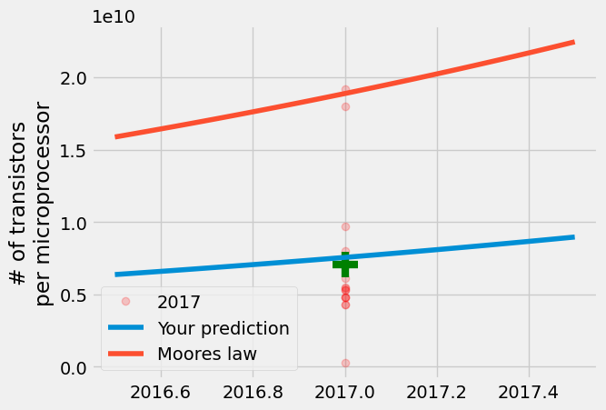

```python
plt.plot(
    2017 * np.ones(np.sum(year == 2017)),
    transistor_count2017,
    "ro",
    label="2017",
    alpha=0.2,
)
plt.plot(2017, transistor_count2017.mean(), "g+", markersize=20, mew=6)

plt.plot(y, your_model2017, label="Your prediction")
plot2 = plt.plot(y, Moore_Model2017, label="Moores law")
plt.ylabel("# of transistors\nper microprocessor")
plt.legend()
```

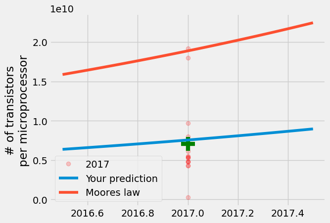

```python
plot2[0].figure
```

```python
IPython.display.SVG(run("""
_←sp.Reset do ⍬
sp←_538 sp
_←sp.SetXRange do y
_←sp.SetYRange do⍎'2.4e10'
_←sp.SetXTickMarks do 0.2
_←sp.SetMarkers do⊂Causeway.Marker.(Dot Plus)
_←sp.SetMarkerColors do Causeway.Color.LightCoral
_←sp.SetMarkerScales do 6
_←sp.SetMargins do 5 15 55 20
_←sp.SetYTickMarks do⍎'0.5e10'
sp.YCaption←'# of transistors',(⎕UCS 10),'per microprocessor'
_←sp.DrawScatterPlot do(transistor_count2017)(2017×(+/year=2017)⍴1)
_←sp.SetMarkerColors do Causeway.Color.Green
_←sp.SetPenWidths do 4
_←sp.SetMarkerScales do 3
_←sp.SetKeyText do'2017' ' ' 'Your prediction' 'Moore''s Law'
_←sp.DrawScatterPlot do,¨(mean transistor_count2017)2017
sp←_538 sp
sp.KeyStyle←sp.KeyStyle+Causeway.KeyStyles.BottomAlign
_←sp.DrawLineGraph do your_model2017 y
_←sp.DrawLineGraph do Moore_Model2017 y
sp.RenderSvg ⍬
"""))
```

[figure not shown]

```python
IPython.display.SVG(run("sp.RenderSvg ⍬"))
```

[figure not shown]

- Least squares: close to mean
- Moore's law: close to max
- Least squares: close to mean
- Moore's law: close to max

## Share as zipped arrays and CSV

- `np.savez`: NumPy arrays for other Python sessions
- APL namespace (also possible: component file)
- `np.savetxt`, `⎕CSV`: CSV

`savez` with `notes=notes`

```python
notes = "the arrays in this file are the result of a linear regression model\n"
notes += "the arrays include\nyear: year of manufacture\n"
notes += "transistor_count: number of transistors reported by manufacturers in a given year\n"
notes += "transistor_count_predicted: linear regression model = exp({:.2f})*exp({:.2f}*year)\n".format(
    B, A
)
notes += "transistor_Moores_law: Moores law =exp({:.2f})*exp({:.2f}*year)\n".format(
    B_M, A_M
)
notes += "regression_csts: linear regression constants A and B for log(transistor_count)=A*year+B"
print(notes)
```

```
the arrays in this file are the result of a linear regression model
the arrays include
year: year of manufacture
transistor_count: number of transistors reported by manufacturers in a given year
transistor_count_predicted: linear regression model = exp(-666.33)*exp(0.34*year)
transistor_Moores_law: Moores law =exp(-675.38)*exp(0.35*year)
regression_csts: linear regression constants A and B for log(transistor_count)=A*year+B
```

```python
run("""
nl←⎕UCS 10
notes←'the arrays in this file are the result of a linear regression model',nl
notes,←'the arrays include',nl,'year: year of manufacture',nl
notes,←'transistor_count: number of transistors reported by manufacturers in a given year',nl
notes,←'transistor_count_predicted: linear regression model = exp(',(1↓2⍕B),')*exp(',(1↓2⍕A),'*year)',nl

notes,←'transistor_Moores_law: Moores law =exp(',(1↓2⍕B_M),')*exp(',(1↓2⍕A_M),'*year)',nl

notes,←'regression_csts: linear regression constants A and B for log(transistor_count)=A*year+B'
⎕←notes
""");
```

```
the arrays in this file are the result of a linear regression model
the arrays include
year: year of manufacture
transistor_count: number of transistors reported by manufacturers in a given year
transistor_count_predicted: linear regression model = exp(¯666.33)*exp(0.34*year)
transistor_Moores_law: Moores law =exp(¯675.38)*exp(0.35*year)
regression_csts: linear regression constants A and B for log(transistor_count)=A*year+B
```

```python
np.savez(
    "mooreslaw_regression.npz",
    notes=notes,
    year=year,
    transistor_count=transistor_count,
    transistor_count_predicted=transistor_count_predicted,
    transistor_Moores_law=transistor_Moores_law,
    regression_csts=(A, B),
)
```

```python
run("""
_ns←⎕NS'notes' 'year' 'transistor_count' 'transistor_count_predicted' 'transistor_Moores_law'
_ns.regression_csts←A B
_←'https://dyalog.github.io/link/4.0/API/Link.Fix'
_←(⊂⎕SE.Dyalog.Array.Serialise _ns)⎕NPUT'mooreslaw_regression.apln' 1

_←'"" "mooreslaw_regression"⎕SE.Link.Fix ⎕SE.Dyalog.Array.Serialise _ns'
""");
```

```python
results = np.load("mooreslaw_regression.npz")
run("""
results←⎕SE.Dyalog.Array.Deserialise⊃⎕NGET'mooreslaw_regression.apln'
""");
```

```python
print(      results["regression_csts"][1])
run("⎕←1↓13⍕results. regression_csts  [2]");
```

```
-666.3264063536233
¯666.3264063521225
```

```python
! ls
```

```
air-quality-data.csv
mooreslaw_regression.apln
mooreslaw_regression.csv
mooreslaw_regression.npz
mooreslaw-tutorial.ipynb
mooreslaw-tutorial.md
mooreslaw-tutorial.slides.html
pairing.md
quadna.dws
r2
save-load-arrays.md
_static
text_preprocessing.py
transistor_data.csv
tutorial-air-quality-analysis.md
tutorial-deep-learning-on-mnist.md
tutorial-deep-reinforcement-learning-with-pong-from-pixels.md
tutorial-ma.md
tutorial-nlp-from-scratch
tutorial-nlp-from-scratch.md
tutorial-plotting-fractals
tutorial-plotting-fractals.md
tutorial-static_equilibrium.md
tutorial-style-guide.md
tutorial-svd.md
tutorial-x-ray-image-processing
tutorial-x-ray-image-processing.md
who_covid_19_sit_rep_time_series.csv
```

```python
run("⎕←↑⎕SH'ls'");
```

```
air-quality-data.csv
mooreslaw_regression.apln
mooreslaw_regression.csv
mooreslaw_regression.npz
mooreslaw-tutorial.ipynb
mooreslaw-tutorial.md
mooreslaw-tutorial.slides.html
pairing.md
quadna.dws
r2
save-load-arrays.md
_static
text_preprocessing.py
transistor_data.csv
tutorial-air-quality-analysis.md
tutorial-deep-learning-on-mnist.md
tutorial-deep-reinforcement-learning-with-pong-from-pixels.md
tutorial-ma.md
tutorial-nlp-from-scratch
tutorial-nlp-from-scratch.md
tutorial-plotting-fractals
tutorial-plotting-fractals.md
tutorial-static_equilibrium.md
tutorial-style-guide.md
tutorial-svd.md
tutorial-x-ray-image-processing
tutorial-x-ray-image-processing.md
who_covid_19_sit_rep_time_series.csv
```

### CSV

- `np.savetxt` with `header=head`
- need 2D array

```python
head = "the columns in this file are the result of a linear regression model\n"
head += "the columns include\nyear: year of manufacture\n"
head += "transistor_count: number of transistors reported by manufacturers in a given year\n"
head += "transistor_count_predicted: linear regression model = exp({:.2f})*exp({:.2f}*year)\n".format(
    B, A
)
head += "transistor_Moores_law: Moores law =exp({:.2f})*exp({:.2f}*year)\n".format(
    B_M, A_M
)
head += "year:, transistor_count:, transistor_count_predicted:, transistor_Moores_law:"
print(head)
```

```
the columns in this file are the result of a linear regression model
the columns include
year: year of manufacture
transistor_count: number of transistors reported by manufacturers in a given year
transistor_count_predicted: linear regression model = exp(-666.33)*exp(0.34*year)
transistor_Moores_law: Moores law =exp(-675.38)*exp(0.35*year)
year:, transistor_count:, transistor_count_predicted:, transistor_Moores_law:
```

```python
run("""
head←'the columns in this file are the result of a linear regression model',nl
head,←'the columns include',nl,'year: year of manufacture',nl
head,←'transistor_count: number of transistors reported by manufacturers in a given year',nl
head,←'transistor_count_predicted: linear regression model = exp(',(1↓2⍕B),')*exp(',(1↓2⍕A),'*year)',nl

head,←'transistor_Moores_law: Moores law =exp(',(1↓2⍕B_M),')*exp(',(1↓2⍕A_M),'*year)',nl

head,←'year:, transistor_count:, transistor_count_predicted:, transistor_Moores_law:'
⎕←head
""");
```

```
the columns in this file are the result of a linear regression model
the columns include
year: year of manufacture
transistor_count: number of transistors reported by manufacturers in a given year
transistor_count_predicted: linear regression model = exp(¯666.33)*exp(0.34*year)
transistor_Moores_law: Moores law =exp(¯675.38)*exp(0.35*year)
year:, transistor_count:, transistor_count_predicted:, transistor_Moores_law:
```

Build 2D array by `np.block`ing 1D vectors with `np.newaxis` (1-col arrays) together

```python
print(  year.shape)
run("⎕←⍴year");

print(   year[:,np.newaxis].shape)
run("⎕←⍴⍪year");
```

```
(179,)
179
(179, 1)
179 1
```

```python
output = np.block(
    [
        year[:, np.newaxis],
        transistor_count[:, np.newaxis],
        transistor_count_predicted[:, np.newaxis],
        transistor_Moores_law[:, np.newaxis],
    ]
)
```

```python
run("""
output←year,transistor_count,transistor_count_predicted,⍪transistor_Moores_law
""");
```

```python
np.savetxt("mooreslaw_regression.csv", X=output, delimiter=",", header=head)
```

```python
! head mooreslaw_regression.csv
```

```
# the columns in this file are the result of a linear regression model
# the columns include
# year: year of manufacture
# transistor_count: number of transistors reported by manufacturers in a given year
# transistor_count_predicted: linear regression model = exp(-666.33)*exp(0.34*year)
# transistor_Moores_law: Moores law =exp(-675.38)*exp(0.35*year)
# year:, transistor_count:, transistor_count_predicted:, transistor_Moores_law:
1.971000000000000000e+03,2.250000000000000000e+03,1.130514785642591733e+03,2.249999999999916326e+03
1.972000000000000000e+03,3.500000000000000000e+03,1.590908400344571419e+03,3.181980515339620069e+03
1.973000000000000000e+03,2.500000000000000000e+03,2.238793840142739555e+03,4.500000000000097316e+03
```

```python
run("""
content←⊂(('^'⎕R'# &')head),nl,output(⎕CSV⍠'Separator' ',')''
_←content ⎕NPUT'mooreslaw_regression.csv' 1
""");
```

```python
run("""
⎕←↑'UTF-8'∘⎕UCS¨⎕UCS¨⎕SH'head mooreslaw_regression.csv'
⎕←''
⎕←↑⎕SH'head mooreslaw_regression.csv'
""");
```

```
# the columns in this file are the result of a linear regression model
# the columns include
# year: year of manufacture
# transistor_count: number of transistors reported by manufacturers in a given year
# transistor_count_predicted: linear regression model = exp(¯666.33)*exp(0.34*year)
# transistor_Moores_law: Moores law =exp(¯675.38)*exp(0.35*year)
# year:, transistor_count:, transistor_count_predicted:, transistor_Moores_law:
1971,2250,1130.514785668682,2249.999999999916
1972,3500,1590.908400380202,3181.98051533962
1973,2500,2238.793840191098,4500.000000000097

# the columns in this file are the result of a linear regression model
# the columns include
# year: year of manufacture
# transistor_count: number of transistors reported by manufacturers in a given year
# transistor_count_predicted: linear regression model = exp(Â¯666.33)*exp(0.34*year)
# transistor_Moores_law: Moores law =exp(Â¯675.38)*exp(0.35*year)
# year:, transistor_count:, transistor_count_predicted:, transistor_Moores_law:
1971,2250,1130.514785668682,2249.999999999916
1972,3500,1590.908400380202,3181.98051533962
1973,2500,2238.793840191098,4500.000000000097
```

## Functions we used

| `np.loadtxt` | ←→ | `⎕CSV` `[;2 3]` `1↓` |
| --- | --- | --- |
| `np.log` | ←→ | `⍟` |
| `np.exp` | ←→ | `*` |
| `lambda` | ←→ | `{⍵}` |
| `plt.semilogy` | ←→ | `Causeway.YAxisStyles.LogScale` |
| `plt.plot` | ←→ | `sp.RenderSvg`, `sp.Draw*` (OOP) |
| `x[:10]` | ←→ | `10↑x` |
| `x[year == 2017]` | ←→ | `(year=2017)/x` or `x[⍸year=2017]` |
| `np.block` | ←→ | `,` `⍪` |
| `np.newaxis` | ←→ | `⍪` |
| `np.savez` | ←→ | `⎕SE.Dyalog.Array.Serialise` `⎕NPUT` |

## Some points

- Specific functions ←→ small composable functions (FP)
- Composing symbols: `⍟ ○*` `⌹ ⎕÷`
- Nested function calls ←→ shallow definitions (debugging context)
- Mature ecosystem (plot styles, exports) ←→ workarounds/hacks/rolling your own

## Some points

- Specific functions ←→ small composable functions (FP)
- Composing symbols: `⍟ ○*` `⌹ ⎕÷`
- Nested function calls ←→ shallow definitions (debugging context)
- Mature ecosystem (plot styles, exports) ←→ workarounds/hacks/rolling your own

# Chat, Q&A

happy little demos?

- Point free appendix
- 1-liner glass cleaner fractal
- Open emacs from RIDE, prefix completion, d.apln jump
- XML: 1-liner ]Defs workflow, https://apl.quest vids

@MaxCan-Code "Max Sun APL"

# Point-free (tacit) demo

- Opinionated takes
- Not liable for mental dmg
- `n+2` letter name/notation/definition/formula/src code?
- see as 1 unit (`poly morph ism` ←→ `polymorphism`):
  - `(B_M×⍨∘*⍨∘*A_M×⊢)`
- vs autocomplete

```python
Moores_law = lambda year: np.exp(B_M) * np.exp(A_M * year)
Moores_law(1971), Moores_law(1973)
```

```
(np.float64(2249.9999999999163), np.float64(4500.000000000097))
```

```python
run("""
_←'Moores_law = lambda year: np.exp(B_M) * np.exp(A_M * year)'
   Moores_law ← {      year←⍵ ⋄  (* B_M) ×      *(A_M × year)}
⎕←                                 (B_M  ×⍨∘*⍨∘ * A_M × ⊢)1971 1973
_←'                                └────────┘'

⎕←(B_M×⍨∘*⍨∘*A_M×⊢)1971 1973
⎕←Moores_law       1971 1973

_←'https://aplcart.info?q=split%20compose (looks better next ver)'
""");
```

```
2250 4500
2250 4500
2250 4500
```

- `n+2` letter name/notation/definition/formula/src code?
- see as 1 unit (`poly morph ism` ←→ `polymorphism`):
  - `(⊣⌹1,∘⍪⊢)`
- vs autocomplete

```python
model = np.polynomial.Polynomial.fit(year, yi, deg=1)
model = model.convert()
B, A = model
print(B ,A)
```

```
-666.3264063536233 0.3416320825591619
```

```python
run("""
⎕←yi⌹(1,⍪year)

⎕←yi  ⌹1, ⍪  year
⎕←yi(⊣⌹1,∘⍪⊢)year
""");
```

```
¯666.3264064 0.3416320826
¯666.3264064 0.3416320826
¯666.3264064 0.3416320826
```

- `n+2` letter name/notation/definition/formula/src code?
- see as 1 unit (`poly morph ism` ←→ `polymorphism`):
  - `(⌈/ , ⌊/ , +/÷≢)`
- vs autocomplete

```python
print(
    transistor_count2017.max(), transistor_count2017.min(), transistor_count2017.mean()
)
```

```
19200000000.0 250000000.0 7050000000.0
```

```python
run("""
mean←{v←⍵ ⋄ (+/v)÷(≢v)}
⎕←(⌈/transistor_count2017)(⌊/transistor_count2017)(mean transistor_count2017)
⎕←(⌈/       ,              ⌊/            ,         +/÷≢) transistor_count2017

⎕←(⌈/,⌊/,+/÷≢)transistor_count2017
""");
```

```
1.92E10 250000000 7050000000
1.92E10 250000000 7050000000
1.92E10 250000000 7050000000
```

## Related Work

- Alan J. Perlis. 1977. In praise of APL: a language for lyrical programming. SIGAPL APL Quote Quad 8, 2 (December 1977), 44–47. https://doi.org/10.1145/586015.586019
- `J`: primary parts of speech:

| noun | ←→ | data |
| --- | --- | --- |
| verb | ←→ | function on nouns |
| adverb | ←→ | modify verb |

https://code.jsoftware.com/wiki/Vocabulary/Words#Parts_Of_Speech

# NumPy vs APL: Behind the Scenes

About me

## Features

Edit in-place

Rich text (Markdown), run code, embed results, transitions, zoom

Interactive, literate (Donald Knuth)

## Code

Py'n'APL

- `⋄` hack

SharpPlot

- Digging, `]Chart`

Make slides like these?

Install: JupterLab

- extension: jupyterlab-rise
- View -> Command Palette -> Open Reveal

(Py'n'APL: docs)

## More tools

Dyalog Jupyter kernel

APL language bar

Jupytext

- ipynb md sync

## Wrap up

1. Features:
   - Edit in-place
   - Markdown text
   - Run code
2. Tools:
   - Py'n'APL
   - SharpPlot
   - JupyterLab + jupyterlab-rise
   - Dyalog Jupyter kernel + APL language bar
   - Jupytext

Slides and source: https://github.com/MaxCan-Code/numpy-tutorials

"Max Sun APL"

- Making documents
- Discuss literate programming

## Questions/Comments/Chat

## Extras

Markdown syntax

https://MaxCan-Code.github.io/numpy-tutorials/content/mooreslaw-tutorial.slides.html

- nbconv template: word-wrap, c/t